# SVM - Supper Vector Machine

##### Realizado por:

- **Nestor Jardany Serrano Rojas**, [GitHub](https://github.com/jardanys)

## OBTENER MNIST (3 & 8)

Generar a bases de datos de **train** y **test** para el número **3** y el número **8**.

```r
train_3 <- readRDS("./RDS/Train_3.rds")
train_8 <- readRDS("./RDS/Train_8.rds")

test_3 <- readRDS("./RDS/Test_3.rds")
test_8 <- readRDS("./RDS/Test_8.rds")

train_3_8 <- rbind(train_3, train_8)
test_3_8 <- rbind(test_3, test_8)
```

## PCA

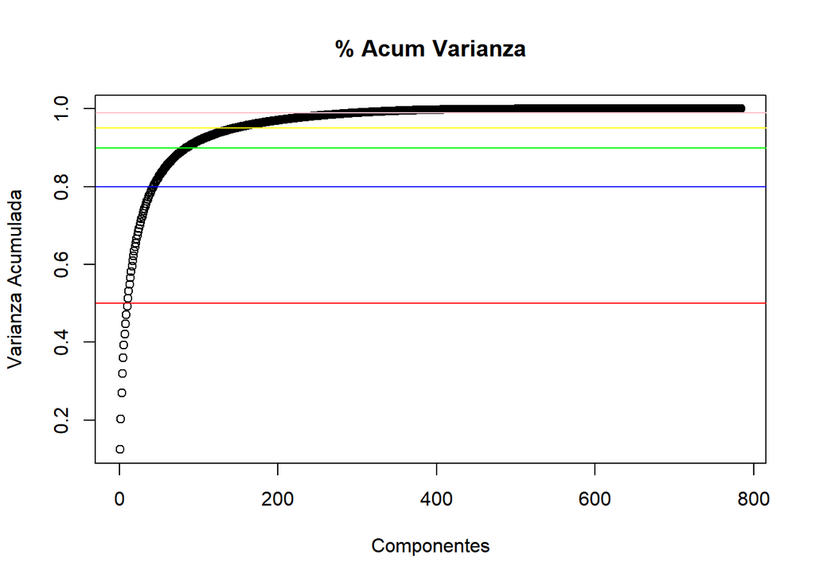

```r
pc <- prcomp(train_3_8[,c(1:784)])
pc_test <- predict(pc, test_3_8[,c(1:784)])
plot(cumsum(pc$sdev^2)/sum(pc$sdev^2), xlab = "Componentes", ylab = "Varianza Acumulada", main = "% Acum Varianza")
abline(h=0.5, col="red")
abline(h=0.8, col="blue")
abline(h=0.9, col="green")
abline(h=0.95, col="yellow")
abline(h=0.99, col="pink")
```

## BASES PCA TRAIN & TEST

Se generan las bases de datos a partir del PCA de la base de train.

- **X** base con fixture de train
- **X_test** base con fixture de test
- **Y** base con vector dependiente de train
- **Y_test** base con vector dependiente de test

```r
X <- pc$x
X_test <- pc_test
y <- as.numeric(as.character(train_3_8[,785]))
y_test <- as.numeric(as.character(test_3_8[,785]))
```

## SVM

Se genera una base de datos con los resultados de todas las iteraciones teniendo en cuenta los siguientes parámetros:

- **Componentes**, para 2, 10, 40, 60, 80, 100.
- **Kernel**, para todas las posibilidades (“linear”, “polynomial”, “radial”, “sigmoid”)
- **Cost**, para 0.1, 1, 10, 100, 1000.

```r
resultados <- data.frame(Componentes=0, Kernel=0, C=0, err_train=0, err_test=0)
Componentes <- c(2, 10, 40, 60, 80, 100)
kernel <- c("linear", "polynomial", "radial", "sigmoid")
C <- c(0.1, 1, 10, 100, 1000)
for(k in Componentes){
      for(i in kernel){
            for(j in C){
                  model_svm <- svm(X[,1:k], as.factor(Y), kernel=i, cost=C)
                  predictivas_train <- predict(model_svm, X[,1:k])
                  predictivas_test <- predict(model_svm, X_test[,1:k])
                  residuales_train <- ifelse(y == predictivas_train,0,1)
                  residuales_test <- ifelse(y_test == predictivas_test,0,1)
                  err_train <- mean(residuales_train)
                  err_test <- mean(residuales_test)
                  resultados <- rbind(resultados, c(k, i, j, err_train, err_test))
            }
      }
}

resultados <- resultados[-1,]
resultado <- resultados
resultados$iteraciones <- c(1:120)
resultados$err_train <- as.numeric(resultados$err_train)
resultados$err_test <- as.numeric(resultados$err_test)
```

```r
resultados <- readRDS("resultados.rds")
kable(resultados, "html") %>%
  kable_styling("striped", full_width = F, position = "center") %>%
  scroll_box(width = "850px", height = "300px")
```

|  | Componentes | Kernel | C | err_train | err_test | iteraciones |
| --- | --- | --- | --- | --- | --- | --- |
| 2 | 2 | linear | 0.1 | 0.1381239 | 0.1320565 | 1 |
| 3 | 2 | linear | 1 | 0.1381239 | 0.1320565 | 2 |
| 4 | 2 | linear | 10 | 0.1381239 | 0.1320565 | 3 |
| 5 | 2 | linear | 100 | 0.1381239 | 0.1320565 | 4 |
| 6 | 2 | linear | 1000 | 0.1381239 | 0.1320565 | 5 |
| 7 | 2 | polynomial | 0.1 | 0.1439659 | 0.1396169 | 6 |
| 8 | 2 | polynomial | 1 | 0.1439659 | 0.1396169 | 7 |
| 9 | 2 | polynomial | 10 | 0.1439659 | 0.1396169 | 8 |
| 10 | 2 | polynomial | 100 | 0.1439659 | 0.1396169 | 9 |
| 11 | 2 | polynomial | 1000 | 0.1439659 | 0.1396169 | 10 |
| 12 | 2 | radial | 0.1 | 0.1363712 | 0.1250000 | 11 |
| 13 | 2 | radial | 1 | 0.1363712 | 0.1250000 | 12 |
| 14 | 2 | radial | 10 | 0.1363712 | 0.1250000 | 13 |
| 15 | 2 | radial | 100 | 0.1363712 | 0.1250000 | 14 |
| 16 | 2 | radial | 1000 | 0.1363712 | 0.1250000 | 15 |
| 17 | 2 | sigmoid | 0.1 | 0.2341012 | 0.2106855 | 16 |
| 18 | 2 | sigmoid | 1 | 0.2341012 | 0.2106855 | 17 |
| 19 | 2 | sigmoid | 10 | 0.2341012 | 0.2106855 | 18 |
| 20 | 2 | sigmoid | 100 | 0.2341012 | 0.2106855 | 19 |
| 21 | 2 | sigmoid | 1000 | 0.2341012 | 0.2106855 | 20 |
| 22 | 10 | linear | 0.1 | 0.0620097 | 0.0524194 | 21 |
| 23 | 10 | linear | 1 | 0.0620097 | 0.0524194 | 22 |
| 24 | 10 | linear | 10 | 0.0620097 | 0.0524194 | 23 |
| 25 | 10 | linear | 100 | 0.0620097 | 0.0524194 | 24 |
| 26 | 10 | linear | 1000 | 0.0620097 | 0.0524194 | 25 |
| 27 | 10 | polynomial | 0.1 | 0.0424804 | 0.0347782 | 26 |
| 28 | 10 | polynomial | 1 | 0.0424804 | 0.0347782 | 27 |
| 29 | 10 | polynomial | 10 | 0.0424804 | 0.0347782 | 28 |
| 30 | 10 | polynomial | 100 | 0.0424804 | 0.0347782 | 29 |
| 31 | 10 | polynomial | 1000 | 0.0424804 | 0.0347782 | 30 |

[output cut: 90 more lines]

## RESULTADOS

Se observan todas la iteraciones realizadas en terminos del error de entrenamiento y error de prueba

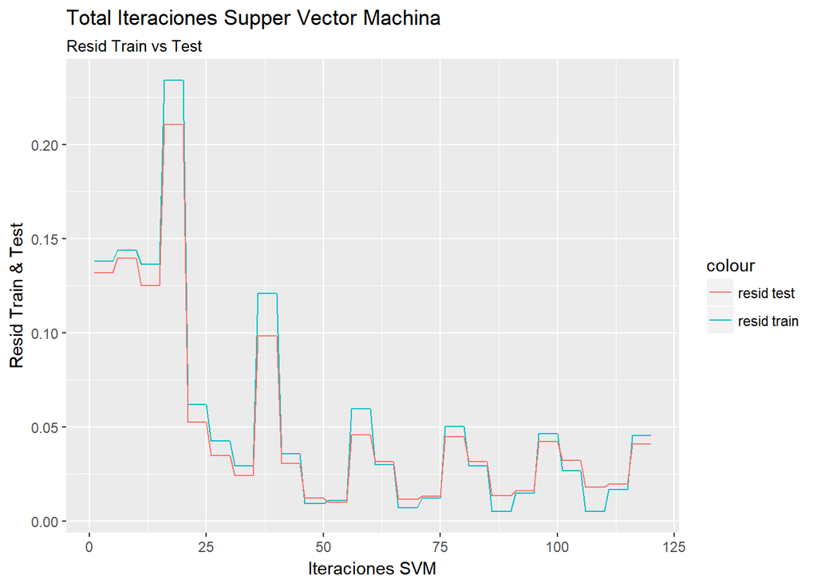

```r
ggplot(resultados, aes(x=iteraciones, y=err_train, colour="resid train")) + geom_line() +
      geom_line(aes(x=iteraciones, y=err_test, colour="resid test")) + xlab("Iteraciones SVM") +
      ylab("Resid Train & Test") + labs(title = "Total Iteraciones Supper Vector Machina",
                                          subtitle = "Resid Train vs Test")
```

## MEJOR MODELO

Para los datos el mejor modelo con menor error de prueba es el siguiente, tiene como parámetros un Kernel Radial, C=0.1 con un error en la base de prueba de 1% aproximadamente.

```r
which.min(resultados$err_test)
```

```
## [1] 51
```

```r
resultados[which.min(resultados$err_test),]
```

```
##    Componentes Kernel   C  err_train   err_test iteraciones
## 52          40 radial 0.1 0.01109998 0.01008065          51
```

2018-04 Nestor Jardany Serrano Rojas

Copyright © All rights reserved.